# Newnes Mortality Recruitment

Model for the effect of mining on plant mortality in Newnes swamps. Code by José R. Ferrer-Paris adapted from David Keith’s original.

# Preliminaries

## libraries

```r
require(tidyverse)
require(ggeffects)
require(tidyverse)
require(lme4)
```

## Data

object name for newnes mortality in detectable resprouters (i.e. dead remains identifiable) - newnmd

```r
newnmd = read.csv("NewnesResprouterMortality_SixDetectableSpp.csv", header=T, row.names=1, stringsAsFactors = FALSE)
```

define variables

```r
(newnmd %>% transmute(Val=Valley, Mine=Undermined, Fire=Fire_interval, RecOrgan=Recovery_Organ, Kill, Respr, Mort=Kill/Tot, Sppf=factor(Species)) -> data)
```

|  | Val | Mine | Fire | RecOrgan | Kill | Respr | Mort | Sppf |
| --- | --- | --- | --- | --- | --- | --- | --- | --- |
| 1 | side | no | 40.0 | L | 7 | 250 | 0.02723735 | Baeckea linifolia |
| 2 | floor | no | 40.0 | L | 0 | 38 | 0.00000000 | Baeckea linifolia |
| 3 | floor | yes | 6.2 | L | 4 | 0 | 1.00000000 | Baeckea linifolia |
| 4 | side | yes | 6.2 | L | 41 | 108 | 0.27516779 | Baeckea linifolia |
| 5 | floor | yes | 6.2 | L | 5 | 0 | 1.00000000 | Baeckea linifolia |
| 6 | side | no | 6.2 | L | 14 | 25 | 0.35897436 | Baeckea linifolia |
| 7 | floor | no | 6.2 | L | 1 | 33 | 0.02941176 | Baeckea linifolia |
| 8 | side | no | 6.2 | L | 2 | 73 | 0.02666667 | Baeckea linifolia |
| 9 | floor | no | 6.2 | L | 0 | 24 | 0.00000000 | Baeckea linifolia |
| 73 | side | no | 40.0 | L | 4 | 1 | 0.80000000 | Epacris paludosa |

[output cut: 52 more lines]

```r
NA
```

# FIRE MORTALITY - DETECTABLE RESPROUTERS

Fit fixed factors first (no random factor)

```r
model <- glm(cbind(Kill,Respr)~Mine*Val, data, family=binomial)
summary(model) # see p. 634 Crawley
```

```
Call:
glm(formula = cbind(Kill, Respr) ~ Mine * Val, family = binomial,
    data = data)

Deviance Residuals:
   Min      1Q  Median      3Q     Max
-7.457  -1.412   0.468   1.722   9.168

Coefficients:
                Estimate Std. Error z value Pr(>|z|)
(Intercept)      -3.9560     0.3569 -11.085  < 2e-16 ***
Mineyes           6.6416     0.4960  13.389  < 2e-16 ***
Valside           2.3959     0.3698   6.479 9.25e-11 ***
Mineyes:Valside  -5.2990     0.5218 -10.155  < 2e-16 ***
---
Signif. codes:  0 ‘***’ 0.001 ‘**’ 0.01 ‘*’ 0.05 ‘.’ 0.1 ‘ ’ 1

(Dispersion parameter for binomial family taken to be 1)

    Null deviance: 981.73  on 61  degrees of freedom
Residual deviance: 426.41  on 58  degrees of freedom
AIC: 510.82

Number of Fisher Scoring iterations: 5
```

There are many extreme values (Full mortality or full resprouting):

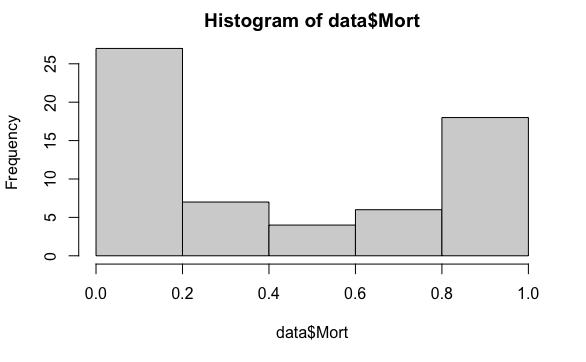

```r
hist(data$Mort)
```

Complementary log-log link might be more appropriate in this case, but results are similar for the fixed effect model (not shown):

```r
model2 <- glm(cbind(Kill,Respr)~Mine*Val, data, family=binomial("cloglog"))
summary(model2)
```

Check overdispersion - is residual dev >1.5 times greater than residual df? YES it is.

```r
model2 <- glmer(cbind(Kill,Respr) ~ Mine * Val + (1|Sppf), dat=data, family = binomial(link = "logit"))
summary(model2)
```

```
Generalized linear mixed model fit by maximum likelihood
  (Laplace Approximation) [glmerMod]
 Family: binomial  ( logit )
Formula: cbind(Kill, Respr) ~ Mine * Val + (1 | Sppf)
   Data: data

     AIC      BIC   logLik deviance df.resid
   327.0    337.7   -158.5    317.0       57

Scaled residuals:
    Min      1Q  Median      3Q     Max
-6.8624 -0.9155 -0.0207  0.7420  8.2104

Random effects:
 Groups Name        Variance Std.Dev.
 Sppf   (Intercept) 1.421    1.192
Number of obs: 62, groups:  Sppf, 6

Fixed effects:
                Estimate Std. Error z value Pr(>|z|)
(Intercept)      -3.7973     0.6072  -6.254 4.00e-10 ***
Mineyes           6.8124     0.5237  13.009  < 2e-16 ***
Valside           2.4465     0.3807   6.426 1.31e-10 ***
Mineyes:Valside  -4.7887     0.5528  -8.662  < 2e-16 ***
---
Signif. codes:  0 ‘***’ 0.001 ‘**’ 0.01 ‘*’ 0.05 ‘.’ 0.1 ‘ ’ 1

Correlation of Fixed Effects:
            (Intr) Mineys Valsid
Mineyes     -0.419
Valside     -0.567  0.654
Mineys:Vlsd  0.393 -0.931 -0.671
```

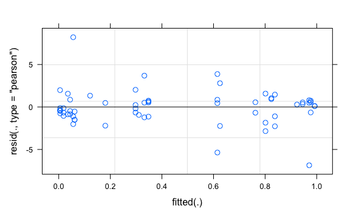

```r
plot(model2)
```

Test the complementary-log-log link, some minor differences in residuals, but higher AIC, so we will ignore for now :

```r
model3 <- glmer(cbind(Kill,Respr) ~ Mine * Val + (1|Sppf), dat=data, family = binomial(link = "cloglog"))
AIC(model2,model3)
```

|  | df | AIC |
| --- | --- | --- |
| model2 | 5 | 327.0372 |
| model3 | 5 | 345.3445 |

This will print the predicted values and CIs :

```r
ggpredict(model2, c("Mine", "Val"))
```

```
# Predicted probabilities of cbind(Kill, Respr)

# Val = floor

Mine | Predicted |       95% CI
-------------------------------
no   |      0.02 | [0.01, 0.07]
yes  |      0.95 | [0.86, 0.99]

# Val = side

Mine | Predicted |       95% CI
-------------------------------
no   |      0.21 | [0.09, 0.41]
yes  |      0.66 | [0.42, 0.84]

Adjusted for:
* Sppf = 0 (population-level)
```

This will plot the same information:

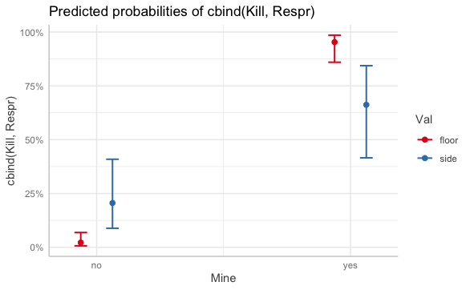

```r
ggpredict(model2, c("Mine", "Val")) %>% plot()
```

```r
NA
NA
```

A boxplot of the predictions (based on the logit model):

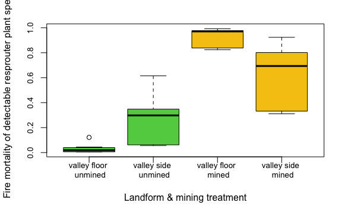

```r
data$prd <- predict(model2,type="response")
boxplot(prd~Val+Mine,data, xlab = "Landform & mining treatment", ylab ="Fire mortality of detectable resprouter plant species",
        cex.axis = 0.85,  names = c("valley floor \n unmined", "valley side \n unmined", "valley floor \n mined", "valley side \n mined"),
        col = c(3,3,7,7))
```

Compare with boxplot of raw values:

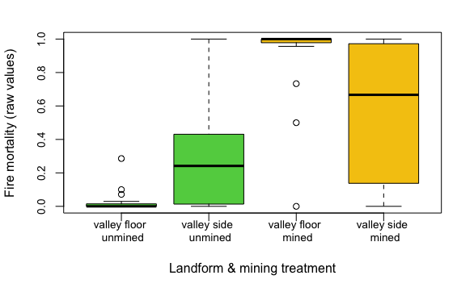

```r
boxplot(Mort ~ Val + Mine, data, xlab = "Landform & mining treatment", ylab ="Fire mortality (raw values)",
        cex.axis = 0.85,  names = c("valley floor \n unmined", "valley side \n unmined", "valley floor \n mined", "valley side \n mined"),
        col = c(3,3,7,7))
```